# R Notebook

```r
load(file = "time-series/Rdata/seurat_integration_brown.RData")
```

[output not shown]

What does the expression of adipogenic markers look like?

[output not shown]

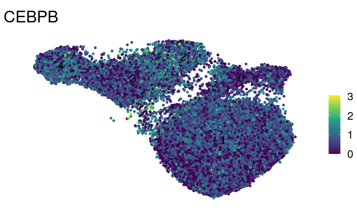

```r
FeaturePlot(s_brown,"CEBPB",label=TRUE,label.size=6,pt.size=1.25)+scale_color_viridis_c()+theme_void(base_size = 20)
```

```r
FeaturePlot(s_brown,"CEBPB",label=TRUE,label.size=6,pt.size=1.25)+scale_color_viridis_c()+theme_void(base_size = 20)
ggsave("/home/rstudio/time-series/figures/brown_integration_with_15/CEBPB.eps",dpi=72, dev='eps', height=6, width=8, units="in")
```

[figure not shown]

```r
ggsave("/home/rstudio/time-series/figures/brown_integration_with_15/CEBPB.eps",dpi=72, dev='eps', height=6, width=8, units="in")
```

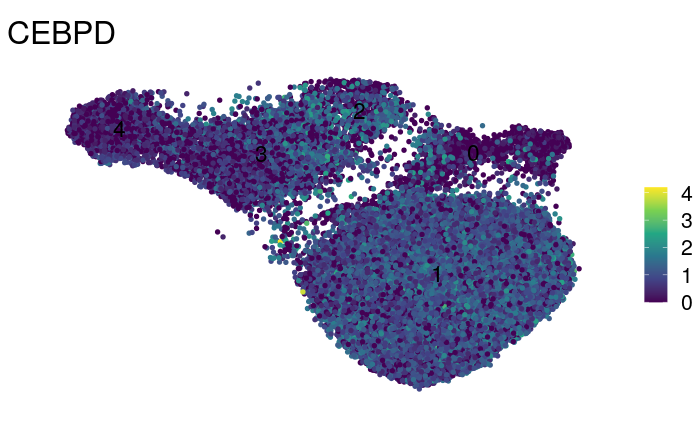

```r
FeaturePlot(s_brown,"CEBPD",label=TRUE,label.size=6,pt.size=1.25)+scale_color_viridis_c()+theme_void(base_size = 20)
```

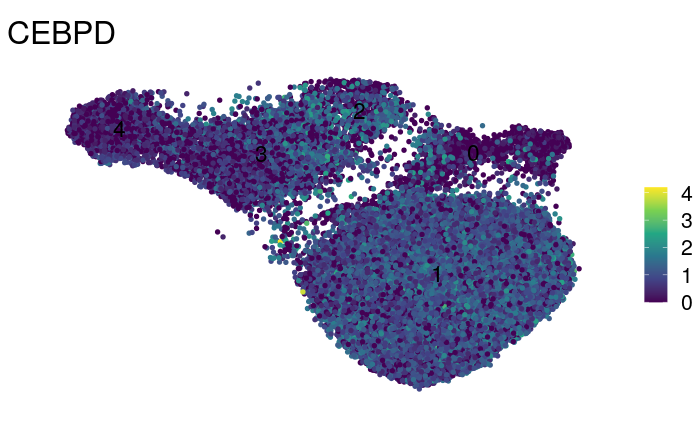

```r
FeaturePlot(s_brown,"CEBPD",label=TRUE,label.size=6,pt.size=1.25)+scale_color_viridis_c()+theme_void(base_size = 20)
ggsave("/home/rstudio/time-series/figures/brown_integration_with_15/CEBPD.eps",dpi=72, dev='eps', height=6, width=8, units="in")
```

What does the expression of BROWN adipogenic marker genes look like? # NO BROWN MARKER GENE IS ENRICHED IN ADIPOGENIC TRAJECTORY ALONE EXCEPT FOR PPARGC1A AND PPARGC1B WHICH ARE ALSO SHOWN IN TFS BELOW

```r
FeaturePlot(s_brown,"FOXO1",label=TRUE,label.size=6,pt.size=1.25)+scale_color_viridis_c()+theme_void(base_size = 20)
```

[output not shown]

What does the expression of adipogenic TFs look like? Are any preferentially expressed in adipogenic trajectory over non adipogenic? # Yes: PPARG, PPARGC1A/1B That would mean looking into brown adipogenesis TFs. # DONE

```r
genes=c("PPARG","CEBPA","CEBPB","CEBPD","ZEB1","NR3C1","STAT5A","PRDM16","NFIA","PPARA","PPARGC1A","PPARGC1B","EBF2")
s_brown=ScaleData(s_brown,features = genes)
DoHeatmap(s_brown,features = genes,raster = FALSE)+scale_fill_viridis(option = "B")
ggsave("/home/rstudio/time-series/figures/brown_integration_with_15/adipo.TF.jpeg",dpi=300, dev='jpeg', height=6, width=8, units="in")
```

[output not shown]

# BROWN ADIPOGENESIS POSITIVE REGULATORS: https://onlinelibrary-wiley-com.libproxy.berkeley.edu/doi/epdf/10.1002/oby.22334

ESRRA mediates thermogenic response.

```r
genes=c("ZNF516", "KLF11", "IRF4", "TAF7L", "ZBTB16", "EWSR1", "PLAC8","ESRRA","ESRRG")
s_brown=ScaleData(s_brown,features = genes)
DoHeatmap(s_brown,features = genes,raster = FALSE)+scale_fill_viridis(option = "B")
```

[output not shown]

# BROWN ADIPOGENESIS NEGATIVE REGULATORS

NR1h3 regulates lipid homeostasis.

```r
genes=c("FOXO1","TWIST1","RBL1","NR1H3", "RB1", "NRIP1", "TLE3", "NR1D1","ZNF423")
s_brown=ScaleData(s_brown,features = genes)
DoHeatmap(s_brown,features = genes,raster = FALSE)+scale_fill_viridis(option = "B")
```

[output not shown]

# Some TFs are activated in non-adipo trajectory whereas others are not. Therefore, the question is what response is illicited in non-adipo trajectory, including TFs, and how is that response different than the one illicited in adipo trajectory?

```r
UMAPPlot(s_brown,label=TRUE)
```

[output not shown]

Why is PPARG not induced in non-adipo trajectory?

```r
m3v2=FindMarkers(s_brown,ident.1 = 3,ident.2 = 2,logfc.threshold = 1,only.pos = T)
```

[output not shown]

# TOP 10 GENES INDUCED IN CLUSTER 1 NOT INDUCED IN CLUSTER 3

```r
setdiff(rownames(m1v0)[1:10],intersect(rownames(m1v0)[1:10],rownames(m3v2)))
```

```
[1] "ABCA6" "NNMT"  "LAMA2" "APOE"  "FBLN1"
```

```r
m0v2=FindMarkers(s_brown,ident.1 = 0,ident.2 = 2,logfc.threshold = .5,only.pos = T)
```

[output not shown]

```r
write.table(x = rownames(m0v2),file = "/home/rstudio/time-series/files/brown_integration/filtered.c0v2.txt",sep = "\n",row.names = FALSE,col.names = FALSE,quote = FALSE,eol = "\n")

m2v0=FindMarkers(s_brown,ident.1 = 2,ident.2 = 0,logfc.threshold = .5,only.pos = T)
```

[output not shown]

```r
write.table(x = rownames(m2v0),file = "/home/rstudio/time-series/files/brown_integration/filtered.c2v0.txt",sep = "\n",row.names = FALSE,col.names = FALSE,quote = FALSE,eol = "\n")
```

```r
m3v1=FindMarkers(s_brown,ident.1 = 3,ident.2 = 1,logfc.threshold = .5,only.pos = T)
```

[output not shown]

```r
write.table(x = rownames(m3v1),file = "/home/rstudio/time-series/files/brown_integration/filtered.c3v1.txt",sep = "\n",row.names = FALSE,col.names = FALSE,quote = FALSE,eol = "\n")

m1v3=FindMarkers(s_brown,ident.1 = 1,ident.2 = 3,logfc.threshold = .5,only.pos = T)
```

[output not shown]

```r
write.table(x = rownames(m1v3),file = "/home/rstudio/time-series/files/brown_integration/filtered.c1v3.txt",sep = "\n",row.names = FALSE,col.names = FALSE,quote = FALSE,eol = "\n")
```

What TFs are activated at early, mid and late stage during brown adipogenesis? What does their expression look like? Are there any TFs that are not induced in non-adipogenic trajectory? I expect lipogenic TFs to be not induced in non-adipo trajectory.

For this, I am starting to work with only adipogenic trajectory. I m filtering out cells that are far off from the main trajectory to avoid artifacts during pseudotemporal ordering.

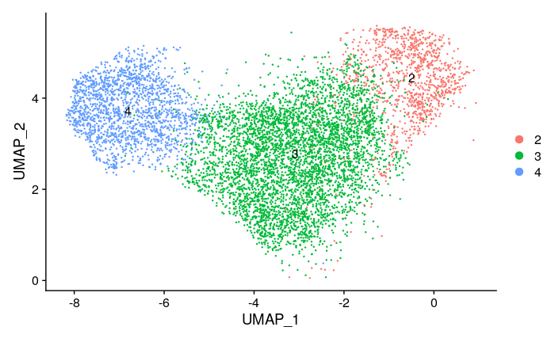